# 클린업 3주차 - Question Answering

이번에는 사전학습된 LLM들을 FT하고, 질의응답 (Question-Answering) 문제를 풀어볼 겁니다.

데이터는 QA 문제를 위한 KorQuAD v1.0 데이터셋을 사용해볼게요!

KorQuAD v1.0 데이터셋은 한국어 질의응답 데이터셋이고, `train`, `dev`로 구성되어 있습니다.

이번 실습은 아래 노트북을 참고했습니다.

https://www.kaggle.com/code/arunmohan003/question-answering-using-bert

**이 코드 실습은 파인 튜닝을 해야 하므로 연산량이 많습니다. 꼭! 하드웨어 가속기를 T4로 바꿔주세요!**

**만약에 본인이 코랩 Pro를 쓰고 있다면 되도록 A100을, 아니면 V100을 사용해주세요**

```python
# !pip install ipywidgets
```

```python
import warnings
warnings.filterwarnings('ignore')
```

## **PEFT란?**

PEFT란 Parameter-Efficient Fine Tuning의 약자로, 사전 훈련된 LLM (Large Language Model)을

특정 상황에 적용할 때, 대부분의 파라미터를 freeze하고, 소수의 모델 파라미터만 fine-tuning하는 기법입니다.

모델이 점점 거대해지면서 일반 GPU로는 파인튜닝이 어렵기 때문에 나온 개념이라고 볼 수 있습니다.

PEFT의 장점은 다음과 같습니다.

1. 매우 적은 학습 비용 - 우리는 PEFT를 통해 당연히 매우 적은 비용으로도 학습이 가능해집니다.
2. Catastrophic forgetting 문제 방지 - 이 문제는 모델이 이전에 학습했던 데이터들을 잊어버리는 현상입니다.

   그러나 PEFT는 매우 적은 파라미터만 파인튜닝하기 때문에 이를 방지할 수 있습니다.

다양한 PEFT 방법들이 존재하지만 대표적인 기법은 LoRa입니다.

LoRa는 Low-Rank Adaptation의 약자로 두 개의 저차원의 행렬로 근사한 후 파인튜닝하는 방법입니다.

**< LoRA를 이용한 파인튜닝 그림 예시 >**

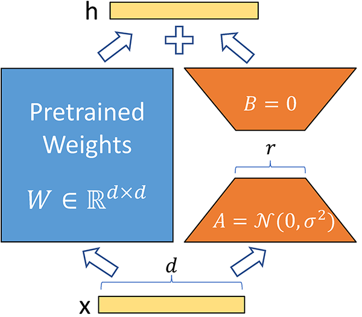

먼저 LoRa가 들어있는 peft 패키지를 설치해줍니다.

설치하는데에 시간이 좀 걸립니다. 이번 실습의 후반부에서 사용할 예정입니다.

```python
!pip install peft
```

# 라이브러리 로드

```python
from urllib.request import urlretrieve
import os
import json
import torch
import torch.nn as nn
from torch.optim import AdamW
from torch.utils.data import TensorDataset, DataLoader
from transformers import BertModel, BertTokenizerFast, AutoModel
from tqdm import tqdm
import numpy as np
from peft import LoraConfig, get_peft_model
```

# KorQuAD v1.0

먼저 데이터를 다운로드 받겠습니다. 아래 URL에 직접 들어가보면, Raw 데이터를 눈으로 확인할 수 있습니다.

```python
# 디렉토리 생성
!mkdir train
!mkdir dev
```

```
mkdir: cannot create directory ‘train’: File exists
mkdir: cannot create directory ‘dev’: File exists
```

```python
# 파일 다운로드
DEV_PATH = "https://raw.githubusercontent.com/monologg/KoBERT-KorQuAD/master/data/KorQuAD_v1.0_dev.json"
TRAIN_PATH = "https://raw.githubusercontent.com/monologg/KoBERT-KorQuAD/master/data/KorQuAD_v1.0_train.json"

urlretrieve(DEV_PATH, "dev/KorQuAD_v1.0_dev.json")
print(f"Downloaded Dev file")

urlretrieve(TRAIN_PATH, "train/KorQuAD_v1.0_train.json")
print(f"Downloaded Train file")
```

```
Downloaded Dev file
Downloaded Train file
```

위의 작업을 통해 json 파일들이 생성되었습니다.

json파일은 JavaScript Object Notation의 약자로, 데이터를 표현하는 표준 방법입니다.

이 파일은 Key, Value 형태의 사전식으로 구성되어 있습니다.

첫 번째 요소만 확인해보겠습니다.

```python
def print_json_tree(data, indent=""):
    for key, value in data.items():
        if type(value) == list:
            print(f'{indent}- {key}: [{len(value)}]')
            print_json_tree(value[0], indent + "  ")
        else:
            print(f'{indent}- {key}: {value}')
```

```python
train_json_path = "train/KorQuAD_v1.0_train.json"

with open(train_json_path) as f:
  train_json = json.load(f)
  print_json_tree(train_json)
```

```
- version: KorQuAD_v1.0_train
- data: [1420]
  - paragraphs: [3]
    - qas: [8]
      - answers: [1]
        - text: 교향곡
        - answer_start: 54
      - id: 6566495-0-0
      - question: 바그너는 괴테의 파우스트를 읽고 무엇을 쓰고자 했는가?
    - context: 1839년 바그너는 괴테의 파우스트을 처음 읽고 그 내용에 마음이 끌려 이를 소재로 해서 하나의 교향곡을 쓰려는 뜻을 갖는다. 이 시기 바그너는 1838년에 빛 독촉으로 산전수전을 다 걲은 상황이라 좌절과 실망에 가득했으며 메피스토펠레스를 만나는 파우스트의 심경에 공감했다고 한다. 또한 파리에서 아브네크의 지휘로 파리 음악원 관현악단이 연주하는 베토벤의 교향곡 9번을 듣고 깊은 감명을 받았는데, 이것이 이듬해 1월에 파우스트의 서곡으로 쓰여진 이 작품에 조금이라도 영향을 끼쳤으리라는 것은 의심할 여지가 없…
  - title: 파우스트_서곡
```

보다시피 질문을 받으면 context에서 답을 찾고 있습니다.

여기서는 "바그너는 괴테의 파우스트를 읽고 무엇을 쓰고자 했는가?" 라는 질문에 "교향곡"이라고 답하고 있죠.

dev 파일도 확인해볼게요

```python
dev_json_path = "dev/KorQuAD_v1.0_dev.json"

with open(dev_json_path) as f:
  dev_json = json.load(f)
  print_json_tree(dev_json)
```

```
- version: KorQuAD_v1.0_dev
- data: [140]
  - paragraphs: [2]
    - qas: [7]
      - answers: [1]
        - text: 1989년 2월 15일
        - answer_start: 0
      - id: 6548850-0-0
      - question: 임종석이 여의도 농민 폭력 시위를 주도한 혐의로 지명수배 된 날은?
    - context: 1989년 2월 15일 여의도 농민 폭력 시위를 주도한 혐의(폭력행위등처벌에관한법률위반)으로 지명수배되었다. 1989년 3월 12일 서울지방검찰청 공안부는 임종석의 사전구속영장을 발부받았다. 같은 해 6월 30일 평양축전에 임수경을 대표로 파견하여 국가보안법위반 혐의가 추가되었다. 경찰은 12월 18일~20일 사이 서울 경희대학교에서 임종석이 성명 발표를 추진하고 있다는 첩보를 입수했고, 12월 18일 오전 7시 40분 경 가스총과 전자봉으로 무장한 특공조 및 대공과 직원 12명 등 22명의 사복 경찰을 …
  - title: 임종석
```

동일하게 잘 되어 있군요!

파일은 Question-Context-Answer 구조로 되어있습니다.

한 번 요소들을 정리해보겠습니다.

- question: context에 대한 질문입니다.
- context: 질문에 해당하는 답을 찾을 수 있는 본문입니다.
- answer: question에 대한 답입니다.
- answer_start: 본문에서 answer가 시작하는 위치입니다.

보다시피 질문을 받으면 context에서 답을 찾고 있습니다.

여기서는 "바그너는 괴테의 파우스트를 읽고 무엇을 쓰고자 했는가?" 라는 질문에 "교향곡"이라고 답하고 있죠.

따라서 context, question, answer를 분리해주겠습니다.

```python
def read_koquad(path):
  with open(path) as f:
    data = json.load(f)

  contexts = []
  questions = []
  answers = []

  for group in data["data"]:
    for passage in group["paragraphs"]:
      context = passage["context"]
      for qa in passage["qas"]:
        question = qa["question"]
        for answer in qa["answers"]:
          answers.append(answer)
          contexts.append(context)
          questions.append(question)
  return contexts, questions, answers

train_contexts, train_questions, train_answers = read_koquad("train/KorQuAD_v1.0_train.json")
dev_contexts, dev_questions, dev_answers = read_koquad("dev/KorQuAD_v1.0_dev.json")
```

```python
print("train context 개수:",len(train_contexts))
print("train question 개수:",len(train_questions))
print("train answer 개수:",len(train_answers))
print("dev context 개수:",len(dev_contexts))
print("dev question 개수:",len(dev_questions))
print("dev answer 개수:",len(dev_answers))
```

```
train context 개수: 60407
train question 개수: 60407
train answer 개수: 60407
dev context 개수: 5774
dev question 개수: 5774
dev answer 개수: 5774
```

# 데이터 전처리

## `answer_start` & `answer_end`

위의 예시를 다시 한 번 보도록 하겠습니다

```python
print_json_tree(train_json)
```

```
- version: KorQuAD_v1.0_train
- data: [1420]
  - paragraphs: [3]
    - qas: [8]
      - answers: [1]
        - text: 교향곡
        - answer_start: 54
      - id: 6566495-0-0
      - question: 바그너는 괴테의 파우스트를 읽고 무엇을 쓰고자 했는가?
    - context: 1839년 바그너는 괴테의 파우스트을 처음 읽고 그 내용에 마음이 끌려 이를 소재로 해서 하나의 교향곡을 쓰려는 뜻을 갖는다. 이 시기 바그너는 1838년에 빛 독촉으로 산전수전을 다 걲은 상황이라 좌절과 실망에 가득했으며 메피스토펠레스를 만나는 파우스트의 심경에 공감했다고 한다. 또한 파리에서 아브네크의 지휘로 파리 음악원 관현악단이 연주하는 베토벤의 교향곡 9번을 듣고 깊은 감명을 받았는데, 이것이 이듬해 1월에 파우스트의 서곡으로 쓰여진 이 작품에 조금이라도 영향을 끼쳤으리라는 것은 의심할 여지가 없…
  - title: 파우스트_서곡
```

```python
print(train_contexts[0][54:])
print()
print(train_answers[0])
```

```
교향곡을 쓰려는 뜻을 갖는다. 이 시기 바그너는 1838년에 빛 독촉으로 산전수전을 다 걲은 상황이라 좌절과 실망에 가득했으며 메피스토펠레스를 만나는 파우스트의 심경에 공감했다고 한다. 또한 파리에서 아브네크의 지휘로 파리 음악원 관현악단이 연주하는 베토벤의 교향곡 9번을 듣고 깊은 감명을 받았는데, 이것이 이듬해 1월에 파우스트의 서곡으로 쓰여진 이 작품에 조금이라도 영향을 끼쳤으리라는 것은 의심할 여지가 없다. 여기의 라단조 조성의 경우에도 그의 전기에 적혀 있는 것처럼 단순한 정신적 피로나 실의가 반영된 것이 아니라 베토벤의 …

{'text': '교향곡', 'answer_start': 54}
```

이 예시에서 알 수 있는 것은 `answer_start`인 54부터 "교향곡"이라고 세 글자의 답이 나온다는 것입니다.

또한 종료, 즉 `answer_end`는 없습니다. 따라서 아래와 같이 answer의 길이만큼 인덱싱 해준다면

우리는 문제에 대한 답을 얻을 수 있겠죠.

```python
# context에서 정답 추출하기

start_idx = train_answers[0]["answer_start"]
answer_len = len(train_answers[0]["text"])
end_idx = start_idx + answer_len

train_contexts[0][start_idx:end_idx]
```

```
'교향곡'
```

그렇다면 context에서 어느 부분이 정답인지 알려주기 위해 train_answers에 `answer_end`도

추가해주면 좋을 것 같습니다. 따라서 아래의 함수를 통해 `answer_end`도 만들어줄게요.

```python
def add_end_idx(answers):
  """
  answers에 answer_end를 추가해주는 함수
  """
  for answer in answers:
    answer["text"] = answer["text"].rstrip()  # 오른쪽 공백 제거
    start_idx = answer["answer_start"]
    end_idx = start_idx + len(answer["text"])
    answer["answer_end"] = end_idx

# train, dev에 대해서 모두 함수 적용하기
add_end_idx(train_answers)
add_end_idx(dev_answers)
```

```python
train_answers[0]
```

```
{'text': '교향곡', 'answer_start': 54, 'answer_end': 57}
```

위와 같이 `answer_end`가 잘 추가된 것을 볼 수 있습니다!

## Tokenizer

이제 Tokenizer를 통해 토큰화 작업을 진행해줄게요!

이번에는 `BertTokenizerFast`를 사용해주도록 하겠습니다.

이 토크나이저는 QA를 위한 유용한 메서드를 가지고 있기 때문에 선택했습니다.

또한 체크포인트는 `klue/bert-base`를 활용해볼게요

```python
tokenizer = BertTokenizerFast.from_pretrained('klue/bert-base')
```

이제 임베딩을 만들어주겠습니다. QA 문제는 Question-Context를 받아서

두 문장 사이의 관계를 파악하는 것이 핵심입니다. 따라서 두 개의 연속된 문장을 넣어주어야 하죠.

BERT 모델은 최대 시퀀스 길이가 512이기 때문에 여기에 맞춰주도록 하겠습니다

```python
train_encodings = tokenizer(train_contexts, train_questions,
          padding=True, truncation=True, max_length=512)
dev_encodings = tokenizer(dev_contexts, dev_questions,
          padding=True, truncation=True, max_length=512)
```

```python
train_encodings[0]
```

```
Encoding(num_tokens=512, attributes=[ids, type_ids, tokens, offsets, attention_mask, special_tokens_mask, overflowing])
```

인코딩을 확인한 결과, 아까하고는 다른 것을 볼 수가 있네요.

각 속성에 대한 설명은 다음과 같습니다.

- `ids`: 임베딩에 대한 정수 인덱스
- `type_ids`: 세그먼트 임베딩 인덱스
- `tokens`: 실제 토큰
- `offsets`: 문장에서 토큰화된 단어의 시작, 끝 offset에 대한 정보
- `attention_mask`: [PAD] 토큰을 제외하면 모두 1

  ex) 1839년 바그너는 -> 183 + 9 + 년 + 바그너 + 는 : 이 때 offset은 각각 (0, 3), (3, 4), (4, 5), (6, 9), (9, 10)

```python
print(train_encodings[0].ids)
print(train_encodings[0].type_ids)
print(train_encodings[0].tokens)
print(train_encodings[0].offsets)
```

```
[2, 13934, 2236, 2440, 27982, 2259, 21310, 2079, 11994, 3791, 2069, 3790, 1508, 2088, 636, 3800, 2170, 3717, 2052, 9001, 8345, 4642, 2200, 3689, 3657, 2079, 19282, 2069, 1363, 2370, 2259, 936, 2069, 554, 2259, 2062, 18, 1504, 4342, 27982, 2259, 13934, 2196, 2440, 2170, 1195, 23260, 6233, 17370, 2113…
[0, 0, 0, 0, 0, 0, 0, 0, 0, 0, 0, 0, 0, 0, 0, 0, 0, 0, 0, 0, 0, 0, 0, 0, 0, 0, 0, 0, 0, 0, 0, 0, 0, 0, 0, 0, 0, 0, 0, 0, 0, 0, 0, 0, 0, 0, 0, 0, 0, 0, 0, 0, 0, 0, 0, 0, 0, 0, 0, 0, 0, 0, 0, 0, 0, 0, 0, 0, 0, 0, 0, 0, 0, 0, 0, 0, 0, 0, 0, 0, 0, 0, 0, 0, 0, 0, 0, 0, 0, 0, 0, 0, 0, 0, 0, 0, 0, 0, 0, 0,…
['[CLS]', '183', '##9', '##년', '바그너', '##는', '괴테', '##의', '파우', '##스트', '##을', '처음', '읽', '##고', '그', '내용', '##에', '마음', '##이', '끌려', '이를', '소재', '##로', '해서', '하나', '##의', '교향곡', '##을', '쓰', '##려', '##는', '뜻', '##을', '갖', '##는', '##다', '.', '이', '시기', '바그너', '##는', '183', '##8', '##년', '##에', '빛', '…
[(0, 0), (0, 3), (3, 4), (4, 5), (6, 9), (9, 10), (11, 13), (13, 14), (15, 17), (17, 19), (19, 20), (21, 23), (24, 25), (25, 26), (27, 28), (29, 31), (31, 32), (33, 35), (35, 36), (37, 39), (40, 42), (43, 45), (45, 46), (47, 49), (50, 52), (52, 53), (54, 57), (57, 58), (59, 60), (60, 61), (61, 62), …
```

그러나 문제가 하나 생겼습니다. 우리는 이전에 답 "교향곡"을 본문에서 찾기 위해서

`answer_start`, `answer_end`를 활용해주었습니다.

하지만 지금은 토큰화되었기 때문에 이 정보를 활용할 수 없습니다.

따라서 토큰화되었을 때 또한 답의 위치를 반영해줄 수 있는 새로운 장치가 필요합니다.

이 때 사용할 수 있는 것이 `char_to_token()` 메서드입니다.

이 메서드는 원본 문장과 인코딩 문장을 비교하여, 원본 문장과 연관되는 인덱스를 반환합니다.

아래처럼 Batch가 있을 때와 없을 때 모두 사용 가능합니다.

- `self.char_to_token(char_index)` if batch size is 1
- `self.char_to_token(batch_index, char_index)` if batch size is greater than 1

예시 정답 몇 개를 확인해보도록 하겠습니다

```python
start_idx = train_encodings.char_to_token(0, train_answers[0]["answer_start"])
end_idx = train_encodings.char_to_token(0, train_answers[0]["answer_end"])
```

```python
# 0번째 정답 확인
print("원본 정답:", train_answers[0]["text"])
print("토큰화 정답:", train_encodings[0].tokens[start_idx:end_idx])
```

```
원본 정답: 교향곡
토큰화 정답: ['교향곡']
```

```python
start_idx = train_encodings.char_to_token(1, train_answers[1]["answer_start"])
end_idx = train_encodings.char_to_token(1, train_answers[1]["answer_end"])
```

```python
# 1번째 정답 확인
print("원본 정답:", train_answers[1]["text"])
print("토큰화 정답:", train_encodings[1].tokens[start_idx:end_idx])
```

```
원본 정답: 1악장
토큰화 정답: ['1', '##악', '##장']
```

보다시피 토큰화가 이루어지더라도 잘 대응된다는 것을 볼 수 있습니다.

하지만 이때, 마지막 `end_idx`가 실제로 마지막 인덱스를 가리키는 것이 아닌 바로 뒤를 가리키므로 -1을 해주어야 합니다

아래의 함수를 통해 업데이트해주도록 할게요

```python
def add_token_positions(encodings, answers) -> list[int]:
    start_positions = []
    end_positions = []
    deleting_list = []

    for i in tqdm(range(len(answers))):
        # 시작 인덱스, 종료 인덱스 찾기
        start_position = encodings.char_to_token(i, answers[i]["answer_start"])
        end_position = encodings.char_to_token(i, answers[i]["answer_end"] - 1)

        start_positions.append(start_position)
        end_positions.append(end_position)

        # 시작 인덱스가 비정상, 즉 본문에 정답이 없는 경우
        if start_positions[-1] is None:
            start_positions[-1] = tokenizer.model_max_length - 1
            deleting_list.append(i)

        # 종료 인덱스가 비정상, 즉 본문에 정답이 없는 경우
        if end_positions[-1] is None:
            end_positions[-1] = tokenizer.model_max_length - 1
            deleting_list.append(i)

    encodings["start_positions"] = start_positions
    encodings["end_positions"] = end_positions
    return list(set(deleting_list))   # 중복 방지
```

```python
deleting_list_for_train = add_token_positions(train_encodings, train_answers)
deleting_list_for_dev = add_token_positions(dev_encodings, dev_answers)
```

위와 같이 토큰화가 완료되었습니다!

다만 여기서 `deleting_list`라는 것을 받아주어야 합니다. 왜 그럴까요?

저희는 문장 전체에 대해 토큰화 한 것이 아닌 최대 512개까지만 토큰화해주었기 때문입니다.

그래서 인코딩에 포함되지 못한 단어들이 존재하게 되죠.

만약 여기 포함되지 못한 단어가 정답이었다면, 학습을 진행할 수 없을 것입니다.

이를 방지하고자 `deleting_list`를 반환해줍니다.

`deleting_list`를 확인해볼까요?

```python
# deleting list 확인하기
print(f"train deleting list ({len(deleting_list_for_train)}) : {deleting_list_for_train}")
print(f"dev deleting list ({len(deleting_list_for_dev)}) : {deleting_list_for_dev}")
```

```
train deleting list (267) : [11776, 24577, 24579, 24580, 29189, 59908, 11788, 11789, 33293, 11791, 33294, 21521, 21522, 37902, 25108, 37907, 38422, 27159, 53271, 59920, 2586, 2587, 44061, 45087, 45090, 14885, 45093, 45102, 45104, 45105, 33844, 45108, 56889, 7739, 52796, 7741, 56895, 54343, 37967, 25…
dev deleting list (57) : [3586, 3589, 3590, 3591, 5191, 5130, 2572, 5134, 2576, 5139, 4246, 4380, 3871, 2979, 5669, 5672, 3502, 3505, 3507, 3509, 3512, 953, 3515, 2876, 3645, 2879, 1090, 2882, 4292, 1093, 5186, 583, 4295, 1097, 586, 3529, 3530, 77, 3533, 3535, 4296, 5193, 3538, 5194, 5195, 5196, 354…
```

이 중에서 `deleting_list_for_train`의 첫 번째를 열어서 확인해보도록 하겠습니다

만약 실제로 너무 뒤쪽에 있어서 정답이 토큰화되어있지 않다면 성공이겠죠

```python
# 첫 번째 확인하기 (원본)
first_deletion = deleting_list_for_train[0]

print("질문:", train_questions[first_deletion])
print("-"*40)
print("원본 문장:", train_contexts[first_deletion])
print("-"*40)
print("정답:", train_answers[first_deletion]["text"])
print("시작/끝 위치:", train_answers[first_deletion]["answer_start"], train_answers[first_deletion]["answer_end"])
```

```
질문: 십자군의 지휘권을 빼앗아 니코폴리스로 진군하기 시작한 인물은?
----------------------------------------
원본 문장: 초기 계획은 존 오브 곤트, 오를레앙 공 루이, 부르고뉴 공국의 용담공 필리프가 1395년에 먼저 출발하고, 다음해 샤를과 리처드가 출발하는 것이었다. 그러나 1396년 초에 이 계획은 폐기되었다. 대신해 느베르의 장이 약 1,000명의 잉글랜드인 분견대와 거의 대부분 부르고뉴 공국의 기병으로 이루어진 약 10,000명의 프랑스군을 조직했다. 바이에른의 팔츠와 뉘른베르크에서 6,000명의 군대가 가세했다.그러나 장 지휘하의 군대의 숫자를 8,000명 정도로 보는 다른 사료도 있다. 이런 상황에서 지기스문트는 자신의 헝가…
----------------------------------------
정답: 느베르
시작/끝 위치: 966 969
```

```python
# 첫 번째 확인하기 (토큰)
print(train_encodings.char_to_token(first_deletion, train_answers[first_deletion]["answer_start"]))
print(train_encodings.char_to_token(first_deletion, train_answers[first_deletion]["answer_end"]))
```

```
None
None
```

둘 다 존재하지 않았네요! 따라서 정답이 존재하지 않는 문장들에 대해서는 제거해주도록 할게요

다만 dev에서는 이 또한 예측의 일부이기 때문에 제거하지 않도록 하겠습니다.

```python
def delete_samples(encodings, deleting_list, is_train=True):
  """
  train일 경우에만 샘플들을 지워줍니다
  """
  if is_train:
    input_ids = np.delete(encodings["input_ids"], deleting_list, axis=0)
    attention_masks = np.delete(encodings["attention_mask"], deleting_list, axis=0)
    start_positions = np.delete(encodings["start_positions"], deleting_list, axis=0)
    end_positions = np.delete(encodings["end_positions"], deleting_list, axis=0)
  else:
    input_ids = encodings["input_ids"]
    attention_masks = encodings["attention_mask"]
    start_positions = encodings["start_positions"]
    end_positions = encodings["end_positions"]

  # X, y를 새로운 축으로 쌓습니다
  X = np.stack((input_ids, attention_masks), axis=0)
  y = np.stack((start_positions, end_positions), axis=0)

  return X, y

X, y = delete_samples(train_encodings, deleting_list_for_train, is_train=True)
X_test, y_test = delete_samples(dev_encodings, deleting_list_for_dev, is_train=False)
```

```python
print("Before deletion")
print(f"train: {len(train_encodings['input_ids'])}")
print(f"dev: {len(dev_encodings['input_ids'])}")
print("After deletion")
print(f"train: {len(X[0])}")
print(f"dev: {len(X_test[0])}")
print("-"*40)
print(f"Deletion percentage: {(len(train_encodings['input_ids']) - len(X[0]))/len(train_encodings['input_ids']):.4f}")
```

```
Before deletion
train: 60407
dev: 5774
After deletion
train: 60140
dev: 5774
----------------------------------------
Deletion percentage: 0.0044
```

대략 0.44% 정도 샘플이 감소했네요!

마지막으로 train, valid로 나누어 주겠습니다.

`sklearn`의 `train_test_split`은 (2, 60140, 512)의 ndarray이기 때문에 변형해주어야 합니다.

```python
# X 크기 확인하기
X.shape
```

```
(2, 60140, 512)
```

```python
# train, valid 나누기
from sklearn.model_selection import train_test_split

train_ids, valid_ids = train_test_split(np.arange(len(X[0])), test_size=0.2, random_state=42)

X_train = X[:, train_ids, :]
y_train = y[:, train_ids]
X_valid = X[:, valid_ids, :]
y_valid = y[:, valid_ids]
```

```python
print("X_train size:", X_train.shape)
print("X_valid size:", X_valid.shape)
print("y_train size:", y_train.shape)
print("y_valid size:", y_valid.shape)
```

```
X_train size: (2, 48112, 512)
X_valid size: (2, 12028, 512)
y_train size: (2, 48112)
y_valid size: (2, 12028)
```

# 모델 학습하기

모델은 기본적인 모델인 `BertModel`를 사용해줄게요. BERT는 허깅페이스에 다양한 문제들을

위한 모델들이 올라와있지만, 여기서는 기본 모델을 응용해서 어떻게 파인튜닝할 수 있는지 알아보겠습니다.

제일 먼저 학습을 위한 Config를 저장해볼게요

```python
# Config 저장
from torch.optim import AdamW

BATCH_SIZE = 32

EPOCHS = 3
LEARNING_RATE = 5e-5

loss_fn = nn.CrossEntropyLoss()
```

## 데이터셋 만들기

모델 학습을 위한 Dataset을 정의해줄게요! 앞에서 만들었던, train, valid, test셋을 통해 만들어주겠습니다.

```python
def create_dataset(X, y):
    """
    TensorDataset으로 만들어줍니다. 이는 이후 DataLoader를 통해 모델 학습에
    사용될 수 있습니다.
    """
    # 튜플 unpacking
    input_ids, attention_masks = X
    start_positions, end_positions = y

    # 각 데이터들을 텐서로 변환
    input_ids = torch.tensor(input_ids, dtype=torch.long)
    attention_masks = torch.tensor(attention_masks, dtype=torch.long)
    start_positions = torch.tensor(start_positions, dtype=torch.long)
    end_positions = torch.tensor(end_positions, dtype=torch.long)

    # 각 텐서들을 묶어서 하나의 Dataset으로 만들어줌
    dataset = TensorDataset(input_ids, attention_masks, start_positions, end_positions)
    return dataset
```

```python
train_dataset = create_dataset(X_train, y_train)
valid_dataset = create_dataset(X_valid, y_valid)
test_dataset = create_dataset(X_test, y_test)

train_dataloader = DataLoader(train_dataset, batch_size=BATCH_SIZE, shuffle=True)
valid_dataloader = DataLoader(valid_dataset, batch_size=BATCH_SIZE, shuffle=False)
test_dataloader = DataLoader(test_dataset, batch_size=BATCH_SIZE, shuffle=False)

device = torch.device("cuda" if torch.cuda.is_available() else "cpu")
```

QA를 위해서 우리는 어떤 것을 예측해야 하는 걸까요?

바로 앞에서 정의했던 **start_index와 end_index**를 예측할 겁니다.

이 둘을 예측하여 그 사이의 값을 정답으로 추론하는 것이죠.

하지만 BertModel의 경우, 단순히 Bert 예측 값만을 만들어냅니다.

이것을 문제에 맞게 변형시키기 위해, `BertModelQA`를 정의해주겠습니다.

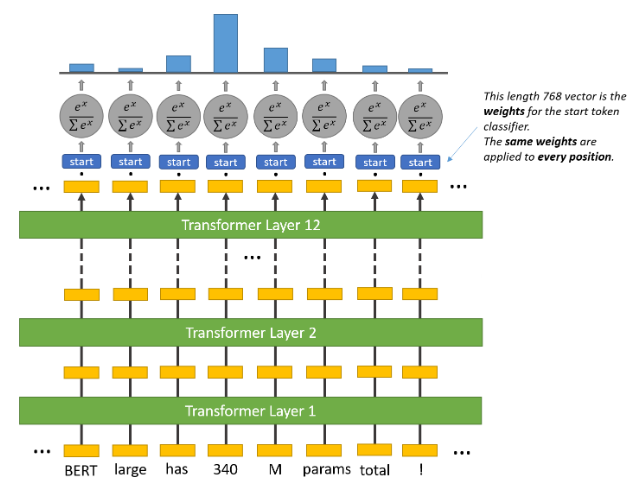

```python
# 모델 정의하기
import torch.nn as nn

class BertModelQA(nn.Module):
    """
    QA를 위한 BertModel입니다.
    start_index, end_index를 예측해야 하므로 2개의 뉴런을 갖는
    qa_outputs 층을 만들어주었습니다.
    """
    def __init__(self, model_name):
        super(BertModelQA, self).__init__()
        self.bert = AutoModel.from_pretrained(model_name)
        self.config = self.bert.config
        self.qa_outputs = nn.Linear(self.bert.config.hidden_size, 2)

    def forward(self, input_ids, attention_mask=None, inputs_embeds=None):
        # outputs[0].shape = (batch_size, sentence_length, 768)
        # 여기서는 (32, 512, 768)
        outputs = self.bert(input_ids, attention_mask)
        sequence_output = outputs[0]

        # (start, end) logit 값을 담은 Output 생성
        logits = self.qa_outputs(sequence_output)  # (32, 512, 2)
        start_logits, end_logits = logits.split(1, dim=-1)  # (32, 512, 1)

        start_logits = start_logits.squeeze(-1)  # (32, 512)
        end_logits = end_logits.squeeze(-1)

        # softmax를 거치면서 확률로 변환
        start_probs = torch.softmax(start_logits, dim=-1)
        end_probs = torch.softmax(end_logits, dim=-1)

        return start_probs, end_probs
```

먼저 아무런 학습 없이 예측해보도록 하겠습니다. 어떤 결과가 나올까요?

`predict_and_evaluate` 함수를 정의해볼게요

```python
def predict_and_evaluate(model, dataloader, loss_fn, is_return=False):
    """
    dataloader를 돌면서 예측 인덱스 값을 얻는 predict와
    평균 손실 값 및 정확도를 계산하는 evaluate를 하는 함수
    is_return=True일 경우, 예측 인덱스를 반환함
    """
    length = len(dataloader) * dataloader.batch_size
    total_loss = 0
    total_acc = 0
    pred_start_index = torch.tensor([], dtype=torch.int).to(device)
    pred_end_index = torch.tensor([], dtype=torch.int).to(device)

    for input_ids, attention_masks, start_positions, end_positions in tqdm(dataloader):
        input_ids = input_ids.to(device)
        attention_masks = attention_masks.to(device)
        start_positions = start_positions.to(device)
        end_positions = end_positions.to(device)

        # 기울기 변화 X
        with torch.no_grad():
          # 모델 예측
          start_probs, end_probs = model(input_ids, attention_masks)

          # 예측 인덱스 반환
          start_index = torch.argmax(start_probs, dim=-1)
          end_index = torch.argmax(end_probs, dim=-1)

          pred_start_index = torch.cat((pred_start_index, start_index), dim=0)
          pred_end_index = torch.cat((pred_end_index, end_index), dim=0)

          # 둘이 동시에 같을 때에만 맞는 것
          correct_start = start_index == start_positions
          correct_end = end_index == end_positions
          correct = torch.sum(correct_start * correct_end)
          total_acc += correct.item()

          # 손실 값 계산
          start_loss = loss_fn(start_probs, start_positions)
          end_loss = loss_fn(end_probs, end_positions)

          # Loss의 평균을 더함
          loss = (start_loss + end_loss) / 2
          total_loss += loss.item()
    avg_loss = total_loss / length
    avg_acc = total_acc / length
    print()
    print(f"Avg Test Loss - {avg_loss} / Avg Test Acc - {avg_acc * 100:.2f}%")

    if is_return:
      outputs = (pred_start_index, pred_end_index)
    else:
      outputs = 0
    return outputs
```

```python
# 예측하기
loss_fn = nn.CrossEntropyLoss()
qa_model = BertModelQA("klue/bert-base")
qa_model.to(device)
outputs = predict_and_evaluate(qa_model, test_dataloader, loss_fn)
```

```
Avg Test Loss - 0.19494795420551828 / Avg Test Acc - 0.00%
```

역시 단 하나도 맞지 않는 것을 볼 수 있네요. 이번에는 파인튜닝을 진행해볼게요.

그러나 그냥 진행한다면 너무나도 시간이 오래 걸리게 됩니다. 1에포크 당 1시간이 넘게 걸리죠..

그리고 모델이 너무 크기 때문에 GPU RAM에 적재조차 안 되며 OOM(Out-of-Memory)가 뜨게 됩니다.

낮은 리소스로는 LLM 모델을 학습시킬 수 없는 걸까요? 그에 대한 대안이 바로 **PEFT**입니다.

저희는 그중 적은 파라미터를 이용하여 파인튜닝을 하는 LoRa를 진행해보겠습니다.

**단, 이 방법 또한 업데이트만 안 할 뿐, 기존의 파라미터를 사용해야 하므로 오래 걸리는 건 동일합니다**

## LoRa

가장 먼저 모델의 학습 가능한 파라미터가 얼마나 있는지 알아보겠습니다

```python
def print_trainable_parameters(model):
    """
    Prints the number of trainable parameters in the model.
    """
    trainable_params = 0
    all_param = 0
    for _, param in model.named_parameters():
        all_param += param.numel()
        if param.requires_grad:
            trainable_params += param.numel()
    print(
        f"trainable params: {trainable_params} || all params: {all_param} || trainable%: {100 * trainable_params / all_param}"
    )
```

```python
print_trainable_parameters(qa_model)
```

```
trainable params: 110618882 || all params: 110618882 || trainable%: 100.0
```

110M 개의 파라미터를 한 번에 파인튜닝시키는 일은 매우 부담이 큰 일입니다.

LoRa를 이용해서 이를 줄여보도록 하겠습니다.

자 그러면 어느 부분에 LoRa를 적용시켜야 할까요? 모델의 구조를 살펴보겠습니다

```python
print(qa_model)
```

```
BertModelQA(
  (bert): BertModel(
    (embeddings): BertEmbeddings(
      (word_embeddings): Embedding(32000, 768, padding_idx=0)
      (position_embeddings): Embedding(512, 768)
      (token_type_embeddings): Embedding(2, 768)
      (LayerNorm): LayerNorm((768,), eps=1e-12, elementwise_affine=True)
      (dropout): Dropout(p=0.1, inplace=False)
    )
    (encoder): BertEncoder(
      (layer): ModuleList(
        (0-11): 12 x BertLayer(
          (attention): BertAttention(
            (self): BertSelfAttention(
              (query): Linear(in_features=768, out_features=768, bias=True)
              (key): Linear(in_features=768, out_features=768, bias=True)
              (value): Linear(in_features=768, out_features=768, bias=True)
              (dropout): Dropout(p=0.1, inplace=False)
            )
            (output): BertSelfOutput(
              (dense): Linear(in_features=768, out_features=768, bias=True)
              (LayerNorm): LayerNorm((768,), eps=1e-12, elementwise_affine=True)
              (dropout): Dropout(p=0.1, inplace=False)
            )
          )
          (intermediate): BertIntermediate(
            (dense): Linear(in_features=768, out_features=3072, bias=True)
            (intermediate_act_fn): GELUActivation()
          )
          (output): BertOutput(
            (dense): Linear(in_features=3072, out_features=768, bias=True)
            (LayerNorm): LayerNorm((768,), eps=1e-12, elementwise_affine=True)
            (dropout): Dropout(p=0.1, inplace=False)
          )
        )
      )
    )
    (pooler): BertPooler(
      (dense): Linear(in_features=768, out_features=768, bias=True)
      (activation): Tanh()
    )
  )
  (qa_outputs): Linear(in_features=768, out_features=2, bias=True)
)
```

모델의 중간에 `encoder` 층이 보입니다. 이 부분에서 `query`, `key`, `value`층이 존재하죠.

그리고 이 연산은 nn.Linear(768, 768)이기 때문에 엄청나게 많은 파라미터 (768 * 768 ~= 600,000)를 사용하는 연산입니다.

또한 12번이나 반복해서 나오기 때문에 매우 큰 연산이 되죠.

따라서 이 부분에 LoRa를 적용시켜 주도록 하겠습니다.

LoRa를 불러와줄게요. 또한 `LoraConfig()` 클래스를 통해 파라미터 설정을 진행해주겠습니다.

각 파라미터 설명은 다음과 같습니다.

- `r`: Lora attention dimension (the "rank")
- `lora_alpha` (`int`): The alpha parameter for Lora scaling.
- `lora_dropout` (`float`): The dropout probability for Lora layers.
- `target_modules`: The names of the modules to apply the adapter to

```python
config = LoraConfig(
    r=32, #attention heads
    lora_alpha=64, #alpha scaling
    target_modules=["query", "key", "value"], #if you know the
    lora_dropout=0.1,
    bias="none",
    task_type="CASUAL_LM" # set this for CLM or Seq2Seq
)
```

```python
model = get_peft_model(qa_model, config)
print_trainable_parameters(model)
```

```
trainable params: 1769472 || all params: 112388354 || trainable%: 1.5744264748285217
```

```python
print(model)
```

```
PeftModel(
  (base_model): LoraModel(
    (model): BertModelQA(
      (bert): BertModel(
        (embeddings): BertEmbeddings(
          (word_embeddings): Embedding(32000, 768, padding_idx=0)
          (position_embeddings): Embedding(512, 768)
          (token_type_embeddings): Embedding(2, 768)
          (LayerNorm): LayerNorm((768,), eps=1e-12, elementwise_affine=True)
          (dropout): Dropout(p=0.1, inplace=False)
        )
        (encoder): BertEncoder(
          (layer): ModuleList(
            (0-11): 12 x BertLayer(
              (attention): BertAttention(
                (self): BertSelfAttention(
                  (query): lora.Linear(
                    (base_layer): Linear(in_features=768, out_features=768, bias=True)
                    (lora_dropout): ModuleDict(
                      (default): Dropout(p=0.1, inplace=False)
                    )
                    (lora_A): ModuleDict(
                      (default): Linear(in_features=768, out_features=32, bias=False)
                    )
                    (lora_B): ModuleDict(
                      (default): Linear(in_features=32, out_features=768, bias=False)
                    )
                    (lora_embedding_A): ParameterDict()
                    (lora_embedding_B): ParameterDict()
                  )
                  (key): lora.Linear(
                    (base_layer): Linear(in_features=768, out_features=768, bias=True)
                    (lora_dropout): ModuleDict(
                      (default): Dropout(p=0.1, inplace=False)
                    )
                    (lora_A): ModuleDict(
                      (default): Linear(in_features=768, out_features=32, bias=False)
                    )
                    (lora_B): ModuleDict(
                      (default): Linear(in_features=32, out_features=768, bias=False)
```

[output cut: 32 more lines]

```
                (LayerNorm): LayerNorm((768,), eps=1e-12, elementwise_affine=True)
                (dropout): Dropout(p=0.1, inplace=False)
              )
            )
          )
        )
        (pooler): BertPooler(
          (dense): Linear(in_features=768, out_features=768, bias=True)
          (activation): Tanh()
        )
      )
      (qa_outputs): Linear(in_features=768, out_features=2, bias=True)
    )
  )
)
```

어떤가요? Q, K, V를 저차원의 행렬로 축소시킴으로써 1.57%의 파라미터만 학습하도록 바꾸었습니다!

이제 학습을 진행해볼까요?

**T4 환경에서는 3시간 30분 정도 걸립니다.**

**V100 환경에서는 1시간 정도 걸립니다**

```python
optimizer = AdamW(model.parameters(), LEARNING_RATE)
loss_fn = nn.CrossEntropyLoss()
```

```python
for epoch in range(EPOCHS):
    total_loss = 0

    for input_ids, attention_masks, start_positions, end_positions in tqdm(train_dataloader):
        input_ids = input_ids.to(device)
        attention_masks = attention_masks.to(device)
        start_positions = start_positions.to(device)
        end_positions = end_positions.to(device)

        # 기울기 변화 초기화
        optimizer.zero_grad()

        # 모델 예측
        start_probs, end_probs = model(input_ids=input_ids, attention_mask=attention_masks)

        # 손실 값 계산
        start_loss = loss_fn(start_probs, start_positions)
        end_loss = loss_fn(end_probs, end_positions)

        # Loss의 평균을 더함
        loss = (start_loss + end_loss) / 2
        total_loss += loss.item()

        # 역전파
        loss.backward()
        optimizer.step()

    avg_loss = total_loss / (len(train_dataloader) * train_dataloader.batch_size)
    print(f"Epoch {epoch+1}: Train Avg Loss - {avg_loss}")

    # Validation
    predict_and_evaluate(model, valid_dataloader, loss_fn)
```

```
Epoch 1: Train Avg Loss - 0.17296282506171376
```

```
Avg Test Loss - 0.16933675114303193 / Avg Test Acc - 75.95%
```

```
Epoch 2: Train Avg Loss - 0.16874379901453218
```

```
Avg Test Loss - 0.168606403026175 / Avg Test Acc - 78.62%
```

```
Epoch 3: Train Avg Loss - 0.16804882449078115
```

```
Avg Test Loss - 0.16842485722550687 / Avg Test Acc - 79.11%
```

80%에 육박하는 높은 정확도를 보이네요!

# 결과 확인하기

자 이제 마지막으로 결과를 확인해볼까요? 우선 테스트 데이터에 대해서 모델을 예측해볼게요

```python
# test 데이터를 예측하고 예측 값을 불러옵니다
preds = predict_and_evaluate(model, test_dataloader, loss_fn, is_return=True)
```

```
Avg Test Loss - 0.16879829253939635 / Avg Test Acc - 77.87%
```

```python
def display_output(test_data, preds, true, tokenizer, n_display=10):
  """
  예측 결과를 출력하는 함수. Default 10개
  """
  pred_s, pred_e = preds

  np.random.seed(1)

  ids = np.random.choice(len(pred_s), n_display)
  for i in ids:
      input_ids, attention_mask, start_position, end_position = test_data[i]
      decoded_text = tokenizer.decode(input_ids)

      true_answer = true[i]["text"]

      context = decoded_text.split("[SEP]")[0].replace("[CLS]", "").strip()
      question = decoded_text.split("[SEP]")[1].strip()

      start_idx = pred_s[i].item()
      end_idx = pred_e[i].item()
      predicted_answer = tokenizer.decode(input_ids[start_idx:end_idx+1])

      print("-"*20, "No", i, "-"*20)
      print(f"Question: {question}")
      print(f"Context: {context}")
      print("-" * 50)
      print(f"True Answer: {true_answer}")
      print(f"Predicted Answer: {predicted_answer}")
      print()
```

```python
# 예측 결과를 출력합니다
display_output(test_dataset, preds, dev_answers, tokenizer)
```

```
-------------------- No 5157 --------------------
Question: 대한민국 제14대 대통령으로 향년 89세를 일기로 서거한 김영삼 대통령의 묘소가 있는 곳은?
Context: 2015년 11월 10일 건강검진 차 서울대학교 병원을 찾아 17일까지 입원한 뒤 퇴원했다. 그러다, 이틀 뒤인 19일 고열과 혈액감염 의심 증세로 서울대학교 병원에 다시 입원한 후, 11월 21일 오후에 증세가 급격히 악화됨에 따라 중환자실로 옮겨졌다. 상태가 전혀 호전되지 않던 김영삼은 결국 2015년 11월 22일 오전 0시 21분 32초에 병마를 물리치지 못하고 혈액 감염 의심으로 치료를 받던 중 향년 89세의 일기로 서거하였다. 사망에 이른 직접적인 원인은 허약한 전신 상태에 패혈증과 급성 심부전이 겹쳐 일…
--------------------------------------------------
True Answer: 국립서울현충원
Predicted Answer:

-------------------- No 235 --------------------
Question: 금강산의 겨울 이름은?
Context: 금강산은 예로부터 국내외에 아름답기로 유명하여, 대대로 많은 예술가들의 표현 대상이 되었다. 봄의 이름인 금강을 포함해 여러 가지 이름이 있지만 현재는 대개 금강산이라 불리며, 계절에 따라 여름에는 봉래산 ( [UNK] [UNK] 山 신선이 사는 산 중 하나 ), 가을에는 풍악산 ( [UNK] [UNK] 山 단풍 든 큰 산, [UNK] [UNK] 山 단풍 언덕 산 ), 겨울에는 개골산 ( [UNK] [UNK] 山 바위 뼈 산 ) 으로 불렸다. 동서로 40킬로미터, 남북으로 60킬로미터, 총면적 530제곱킬로미터로 수…
--------------------------------------------------
True Answer: 개골산
Predicted Answer: 개골산

-------------------- No 3980 --------------------
Question: 유관순 열사는 당시 어떤 종교를 믿고 있었는가?
Context: 감리교회는 일찍이 전래 당시 조선의 독립을 위해 노력한 교단이었다. 아펜젤러 선교사는 한국의 독립운동에 깊이 관여하여 독립협회 창설에 도움을 주었으며, 배재학당 출신 이승만을 옥중지원했으며, 3. 1독립 선언을 한 33인중 이필주, 신석구 등 감리교인 9명은 장로교인 7명 함께 개신교 대표로 참여했다. 이후 일제 탄압을 받았고, 독립운동에도 직간접적으로 참여하였고, 유관순 열사는 감리교인이었다. 특히 스크랜턴 선교사는 전덕기를 전도하여 서울 숭례문 ( 남대문 ) 에 있던 상동감리교회에서 감리교청년 연합회인 [UNK]…
--------------------------------------------------
True Answer: 감리교
Predicted Answer: 감리교회

-------------------- No 5192 --------------------
Question: 1997년 10월 23일, 국회 본회의 대표 연설에서 전두환, 노태우 전 대통령에 대한 사면을 촉구한 새정치 국민회의 의원은?
Context: 이런 집권당에서의 사면 논의에 대해 1997년 8월 31일, 97년 대선을 앞두고 당시 김대중 새정치국민회의 대통령 후보는 간담회에서 " 김영삼 대통령 임기중에 전두환 노태우를 사면하여 동서화합의 길이 열리도록 하겠다 " 는 의견을 밝혔다. 그는 이어 " 그들 ( 전두환 노태우 ) 이 잘못을 반성하지 않는다고 우리도 똑같이 대응할 수는 없다 " 고 밝혔다. 그리고 다음날인 9월 1일 SBS 대통령 후보와 함께라는 프로그램에서 김대중 총재는 전두환 노태우에 대한 용서론을 강조했다. 이렇게 김대중후보가 전두환 노태우 사…
--------------------------------------------------
True Answer: 박정수
Predicted Answer: 박정수

-------------------- No 905 --------------------
Question: 셰르징거가 찾아왔다가 우연히 푸시캣 돌스에 영입된 곳은?
Context: 2003년, 오디션 프로그램 팝스타즈의 우승자로 구성된 그룹 에덴스 크러쉬의 전 멤버였던 니콜 셰르징거가 푸시캣 돌스의 리드보컬로 영입되었다. 이전부터 그룹 활동에 지쳐있던 셰르징거는 솔로 레코딩 계약을 위해 인터스코프 레코드를 찾았다가 뜻하지 않게 푸시캣 돌스에 영입되었다는 후문이다. 같은 해 보컬 멜로디 [UNK] 카야 존스 역시 그룹에 영입되었다. 초기의 그룹은 니콜 셰르징거, 멜로디 [UNK], 카야 존스, 로빈 안틴, 카밋 버처, 사이아 배튼, 캐이시 캠벨, 킴벌리 와이어트, 애슐리 로버츠, 제시카 수타 등…
--------------------------------------------------
True Answer: 인터스코프 레코드
Predicted Answer: 인터스코프 레코드

-------------------- No 2763 --------------------
Question: 대승광오온론에 따르면 패괴 즉 깨어지고 부서진다는 뜻은?
Context: 《 대승광오온론 》 의 해설에 따르면, 살가야견 ( [UNK] [UNK] [UNK] 見 ) 이라는 낱말에서 살 ( [UNK], 산스크리트어 : sat ) 은 패괴 ( [UNK] [UNK] ) 즉 깨어지고 부서진다는 뜻이며, 가야 ( [UNK] [UNK], 산스크리트어 : [UNK] ) 는 화합적취 ( 和 合 [UNK] [UNK] ) 즉 화합하여 쌓인다는 뜻이다. 따라서, 살가야 ( [UNK] [UNK] [UNK] ) 는 패괴 ( [UNK] [UNK] ) 의 적집 ( [UNK] 集 : 쌓인 것 ) 즉 무상 ( 無 常 …
--------------------------------------------------
True Answer: 살
```

[output cut: 14 more lines]

```
Predicted Answer: 마산

-------------------- No 144 --------------------
Question: 중화민국 수립 후 임세영은 자신의 스승이었던 누구를 재조명하는 작업에 착수하였는가?
Context: 임세영은 자신의 제자들과 연극을 구경하러 갔다가 우연히 깡패들과 시비가 붙었는데 깡패들이 임세영의 무공이 고강한 것을 알고 물러갔으나 임세영이 홀로 있을 때 몰래 기습을 해왔다. 그러자 임세영은 그들의 무리수가 많아 방어만 하기에는 곤란한 것을 깨닫고 할 수 없이 공격을 하여 깡패들을 쓰러뜨렸으나 결국 광주 전역에 임세영을 체포한다는 수배령이 내려졌다. 그러자 임세영은 몸을 피해 다른 지역으로 달아났다가 반청의 무리를 모아 청나라를 멸망시키고 중화민국을 세우는데 공헌하게 된다. 중화민국 수립 후 광주로 돌아온 임세영…
--------------------------------------------------
True Answer: 황비홍
Predicted Answer: 황비홍

-------------------- No 4225 --------------------
Question: CA3의 신호가 차단될 경우 손상되는 공간 관련 능력은?
Context: 연구자들은 CA3가 아닌 내후각피질로부터 공간적인 반응이나 장소 기억에 관여하는 신호가 오는지 확인하고 싶었다. 그래서 CA3에서 CA1으로 전달되는 신호 경로를 차단시키고 내후각피질로부터 오는 영향만 관찰했다. 그 결과 CA1 지역에 있는 장소세포들은 정확하고 안정적인 place field를 형성하였으며, 쥐의 경우에 공간인식 실험을 잘 수행하는 것을 확인할 수 있었다. 반면에 CA3의 신호가 차단된 경우에 공간에 대한 회상능력은 손상되었음을 알게 되었다. 이러한 결과는 해마에 최소 두 가지의 서로 기능적으로 분리…
--------------------------------------------------
True Answer: 회상능력
Predicted Answer: 회상능력
```